# Creating an R project

# Forward

A clean environment to organise code, reports, data sets and documentation is crucial in large analytical projects.

The `create_project` function automatically creates a clean template environment, along with an R project file–anchoring working directories to enable simultaneously working across multiple projects. It works across all platforms–Windows, Mac, and Linux.

This vignette walks though what to expect in this project.

```r
library(WAACHShelp) # Let's load the WAACHShelp package
```

# Function specifics

The `create_project` has a small set of arguments:

- Project name
  - `project_name`
- Folders – should the following folders be created for the project? The default for these is `TRUE`.
  - `data`
  - `reports`
  - `output`
  - `docs`
- Other folders
  - Should any other folders (not contained in the above) be created?

# Running the function

Suppose we have just created an empty folder for a project wherever we like (could be local, in a network drive, etc.).

## Step 1:

Create a folder for our project contents to sit.

For the sake of this example, I have created a folder called “test_project” in Documents.

[figure not shown]

Empty folder called `test_project` in My Documents

## Step 2:

Now we can run our function in R. This can be done from a null project, or from terminal.

I have left all of the `data`, `reports`, `output`, arguments as default (`TRUE`). This means they will all be created.

```r
create_project(project_name = "test_project")
```

This opens the following window:

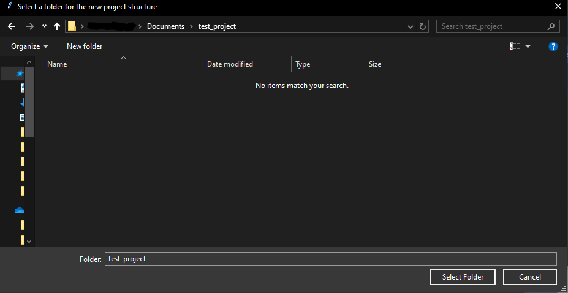

Navigate to the `test_project` folder we created earlier.

## Step 3:

Done!

All of the folders have been created, in addition to an R project that takes the name given by the `project_name` argument.

[figure not shown]